# Final Project: Multi-Path AIC Model Selection

Nimra Ismail

# 1. Introduction

This report demonstrates the functionality of the **FinalProjectNimra** R package, which implements multi-path model selection using AIC with resampling-based stability and plausible model filtering. The package supports both **linear (Gaussian)** and **logistic (Binomial)** regression models.

# 2. Synthetic Gaussian Example

This section reproduces the base-R style example for Gaussian (linear) data.

```r
set.seed(1)
n <- 120; p <- 8
X <- matrix(rnorm(n * p), n, p)
beta <- c(2, -1.5, 0, 0, 1, rep(0, p - 5))
y <- X %*% beta + rnorm(n, sd = 1)
colnames(X) <- paste0("x", 1:p)
df <- as.data.frame(cbind(y, X))

# Run the multi-path AIC pipeline
res_sim <- multi_path_AIC_procedure(df, response = "y", K = 4, B = 10, delta = 1, tau = 0.6)
```

```
## Detected model type: linear
## === STEP 1: Multi-path search on full data ===
##
## Step 1
## Number of models kept: 1
## Model 1 : V1 | AIC = -7967.157
##
## Step 2
## Number of models kept: 1
## Model 1 : V1, x8 | AIC = -7969.445
##
## Step 3
## Number of models kept: 2
## Model 1 : V1, x8, x4 | AIC = -7970.703
## Model 2 : V1, x8, x6 | AIC = -7969.814
##
## Step 4
## No further AIC improvement. Stopping at step 4
##
## === STEP 2: Stability estimation with resampling ===
##
## Bootstrap sample 1 of 10
##
## Step 1
## Number of models kept: 1
## Model 1 : x4 | AIC = 600.333
##
## Step 2
## No further AIC improvement. Stopping at step 2
##
## Bootstrap sample 2 of 10
##
## Step 1
## Number of models kept: 1
## Model 1 : x8 | AIC = 596.686
##
## Step 2
## No further AIC improvement. Stopping at step 2
##
## Bootstrap sample 3 of 10
```

[output cut: 84 more lines]

```
##   <chr>        <dbl>
## 1 x7             0.3
## 2 x8             0.3
## 3 x4             0.2
## 4 x6             0.2
## 5 x1             0.1
## 6 x2             0.1
## 7 x3             0.1
## 8 V1             0
## 9 x5             0
##
## === STEP 3: Selecting plausible, stable models ===
## No plausible models found under current thresholds.
##
## === DONE ===
```

```r
res_sim$plausible_models
```

```
## named list()
```

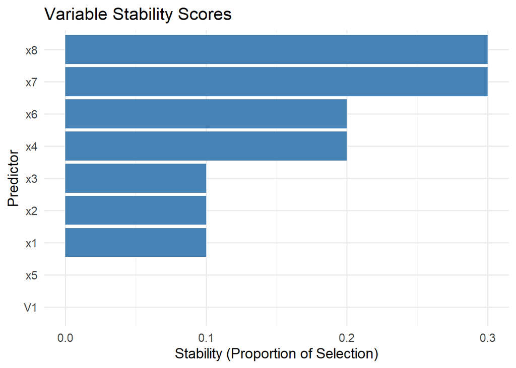

```r
plot_stability(res_sim$stability)
```

# 3. Linear Regression Example (mtcars: Gaussian)

We now apply the method to the **mtcars** dataset, treating `mpg` as a continuous outcome.

```r
set.seed(123)
final_linear <- multi_path_AIC_procedure(mtcars, response = "mpg", K = 4, B = 20, delta = 1, tau = 0.6)
```

```
## Detected model type: linear
## === STEP 1: Multi-path search on full data ===
##
## Step 1
## Number of models kept: 1
## Model 1 : wt | AIC = 166.029
##
## Step 2
## Number of models kept: 3
## Model 1 : wt, cyl | AIC = 156.01
## Model 2 : wt, hp | AIC = 156.652
## Model 3 : wt, qsec | AIC = 156.72
##
## Step 3
## Number of models kept: 6
## Model 1 : wt, cyl, hp | AIC = 155.477
## Model 2 : wt, cyl, qsec | AIC = 156.19
## Model 3 : wt, cyl, carb | AIC = 155.617
## Model 4 : wt, hp, cyl | AIC = 155.477
## Model 5 : wt, hp, am | AIC = 156.135
## Model 6 : wt, qsec, am | AIC = 154.119
##
## Step 4
## No further AIC improvement. Stopping at step 4
##
## === STEP 2: Stability estimation with resampling ===
##
## Bootstrap sample 1 of 20
##
## Step 1
## Number of models kept: 1
## Model 1 : wt | AIC = 158.457
##
## Step 2
## Number of models kept: 2
## Model 1 : wt, hp | AIC = 147.639
## Model 2 : wt, qsec | AIC = 148.061
##
## Step 3
## Number of models kept: 2
```

[output cut: 370 more lines]

```
##  4 carb          0.45
##  5 disp          0.35
##  6 qsec          0.35
##  7 am            0.35
##  8 drat          0.15
##  9 gear          0.15
## 10 vs            0.05
##
## === STEP 3: Selecting plausible, stable models ===
## Plausible, stable models:
## Model 1 : wt, cyl, hp | AIC = 155.477 | Avg. Stability = 0.72
## Model 2 : wt, cyl, carb | AIC = 155.617 | Avg. Stability = 0.68
## Model 3 : wt, hp, cyl | AIC = 155.477 | Avg. Stability = 0.72
##
## === DONE ===
```

```r
final_linear$plausible_models
```

```
## $hp
## $hp$variables
## [1] "wt"  "cyl" "hp"
##
## $hp$AIC
## [1] 155.4766
##
## $hp$avg_stability
## [1] 0.7166667
##
##
## $carb
## $carb$variables
## [1] "wt"   "cyl"  "carb"
##
## $carb$AIC
## [1] 155.6175
##
## $carb$avg_stability
## [1] 0.6833333
##
##
## $cyl
## $cyl$variables
## [1] "wt"  "hp"  "cyl"
##
## $cyl$AIC
## [1] 155.4766
##
## $cyl$avg_stability
## [1] 0.7166667
```

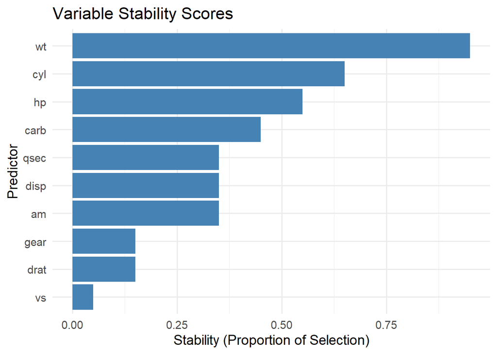

```r
plot_stability(final_linear$stability)
```

**Figure 2:** Stability plot for the linear regression model (`mpg`). Variables with higher stability are robustly associated with fuel efficiency.

# 4. Synthetic Logistic Example (Binomial)

To align with Section 5.2 requirements, we generate synthetic binary data following a logistic model.

```r
set.seed(2)
n <- 200; p <- 6
Xb <- matrix(rnorm(n * p), n, p)
linpred <- 1.2 * Xb[, 1] - 1 * Xb[, 2] + 0.8 * Xb[, 5]
prob <- 1 / (1 + exp(-linpred))
ybin <- rbinom(n, 1, prob)
colnames(Xb) <- paste0("x", 1:p)
dfb <- as.data.frame(cbind(y = ybin, Xb))

# Apply the package’s logistic model selection
res_logit_sim <- multi_path_AIC_procedure(dfb, response = "y", K = 4, B = 10, delta = 1, tau = 0.6)
```

```
## Detected model type: logistic
## === STEP 1: Multi-path search on full data ===
##
## Step 1
## Number of models kept: 1
## Model 1 : x1 | AIC = 241.064
##
## Step 2
## Number of models kept: 1
## Model 1 : x1, x2 | AIC = 217.996
##
## Step 3
## Number of models kept: 1
## Model 1 : x1, x2, x5 | AIC = 198.576
##
## Step 4
## No further AIC improvement. Stopping at step 4
##
## === STEP 2: Stability estimation with resampling ===
##
## Bootstrap sample 1 of 10
##
## Step 1
## Number of models kept: 1
## Model 1 : x1 | AIC = 233.348
##
## Step 2
## Number of models kept: 1
## Model 1 : x1, x5 | AIC = 212.964
##
## Step 3
## Number of models kept: 1
## Model 1 : x1, x5, x2 | AIC = 201.457
##
## Step 4
## No further AIC improvement. Stopping at step 4
##
## Bootstrap sample 2 of 10
##
## Step 1
```

[output cut: 149 more lines]

```
## # A tibble: 6 × 2
##   Variable Stability
##   <chr>        <dbl>
## 1 x1               1
## 2 x2               1
## 3 x5               1
## 4 x3               0
## 5 x4               0
## 6 x6               0
##
## === STEP 3: Selecting plausible, stable models ===
## Plausible, stable models:
## Model 1 : x1, x2, x5 | AIC = 198.576 | Avg. Stability = 1
##
## === DONE ===
```

```r
res_logit_sim$plausible_models
```

```
## $x5
## $x5$variables
## [1] "x1" "x2" "x5"
##
## $x5$AIC
## [1] 198.5757
##
## $x5$avg_stability
## [1] 1
```

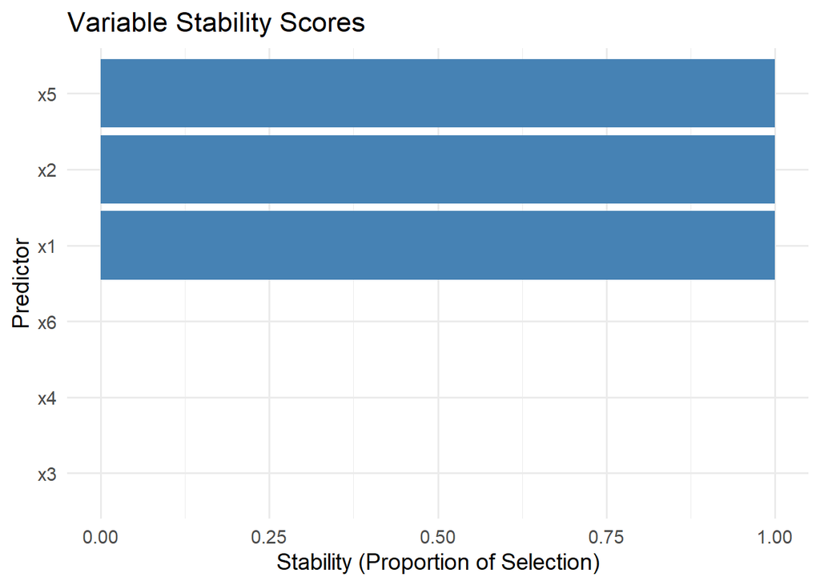

```r
plot_stability(res_logit_sim$stability)
```

**Figure 3:** Stability of predictors for the synthetic logistic dataset. Variables with high stability indicate consistent inclusion across bootstrap samples.

# 5. Logistic Regression Example (mtcars: Binomial)

We now analyze the `mtcars` dataset, treating `am` (0 = automatic, 1 = manual) as the binary outcome.

```r
set.seed(123)
final_logistic <- multi_path_AIC_procedure(mtcars, response = "am", K = 4, B = 20, delta = 1, tau = 0.6)
```

```
## Detected model type: logistic
## === STEP 1: Multi-path search on full data ===
##
## Step 1
## Number of models kept: 1
## Model 1 : gear | AIC = 19.276
##
## Step 2
## Number of models kept: 1
## Model 1 : gear, wt | AIC = 6
##
## Step 3
## No further AIC improvement. Stopping at step 3
##
## === STEP 2: Stability estimation with resampling ===
##
## Bootstrap sample 1 of 20
##
## Step 1
## Number of models kept: 1
## Model 1 : wt | AIC = 17.092
##
## Step 2
## Number of models kept: 4
## Model 1 : wt, hp | AIC = 6
## Model 2 : wt, qsec | AIC = 6
## Model 3 : wt, gear | AIC = 6
## Model 4 : wt, carb | AIC = 6
##
## Step 3
## No further AIC improvement. Stopping at step 3
##
## Bootstrap sample 2 of 20
##
## Step 1
## Number of models kept: 1
## Model 1 : gear | AIC = 17.46
##
## Step 2
## Number of models kept: 1
```

[output cut: 255 more lines]

```
##  2 gear          0.85
##  3 qsec          0.3
##  4 disp          0.2
##  5 hp            0.2
##  6 drat          0.2
##  7 mpg           0.15
##  8 carb          0.15
##  9 vs            0.05
## 10 cyl           0
##
## === STEP 3: Selecting plausible, stable models ===
## Plausible, stable models:
## Model 1 : gear, wt | AIC = 6 | Avg. Stability = 0.92
##
## === DONE ===
```

```r
final_logistic$plausible_models
```

```
## $wt
## $wt$variables
## [1] "gear" "wt"
##
## $wt$AIC
## [1] 6
##
## $wt$avg_stability
## [1] 0.925
```

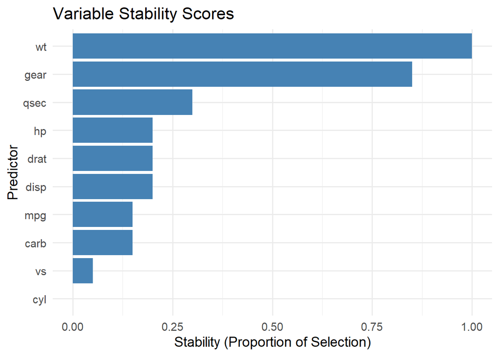

```r
plot_stability(final_logistic$stability)
```

**Figure 4:** Stability plot for the logistic regression model (`am`). Strongly stable variables suggest robust association with transmission type.

# 6. Discussion

The package demonstrates: - **Multi-path forward selection** with AIC improvement criteria. - **Resampling-based stability estimation** for identifying robust predictors. - **Plausible model selection** using AIC tolerance and average stability thresholds.